# Analyzing DDOT projects

**NEW JERSEY AVE NW (2020)**

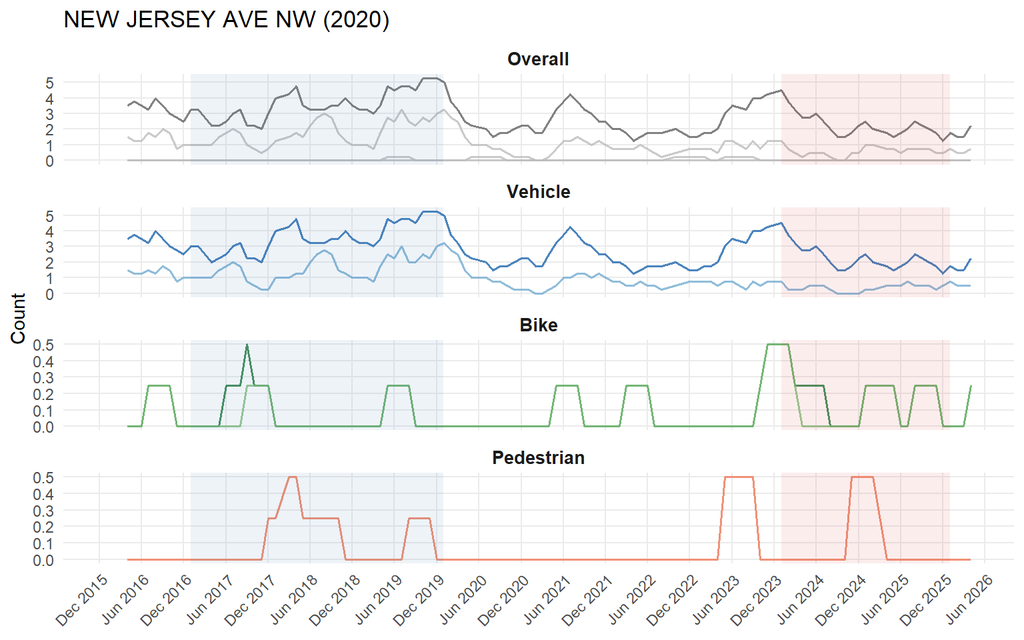

| Outcome | Before, per month | After, per month | % change |
| --- | --- | --- | --- |
| All Crashes | 3.56 | 1.96 | -44.9 |
| Injury Crashes | 1.78 | 0.50 | -71.9 |
| Serious Injury Crashes | 0.03 | 0.00 | -100.0 |
| Fatal Crashes | 0.00 | 0.00 | NaN |
| Vehicle Crashes | 3.53 | 1.96 | -44.5 |
| Bike Crashes | 0.08 | 0.12 | 50.0 |
| Pedestrian Crashes | 0.11 | 0.08 | -25.0 |
| Driver Injury | 1.61 | 0.33 | -79.3 |
| Bicyclist Injury | 0.06 | 0.08 | 50.0 |
| Pedestrian Injury | 0.11 | 0.08 | -25.0 |

**Change in micromobility usage**  
2019 micromobility trips: 80  
Avg. of ’24 & ’25 trips: 2,408  
Increase in trips: 2,328  
% increase: 2,910

**PENNSYLVANIA AVE SE (2023)**

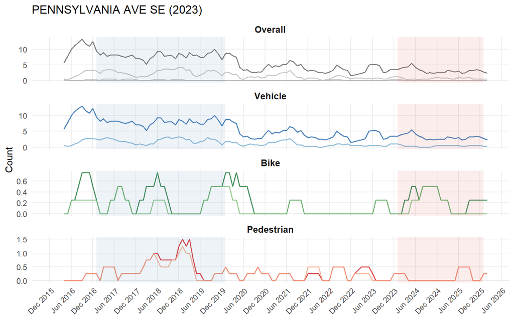

| Outcome | Before, per month | After, per month | % change |
| --- | --- | --- | --- |
| All Crashes | 7.72 | 3.12 | -59.5 |
| Injury Crashes | 2.58 | 0.58 | -77.4 |
| Serious Injury Crashes | 0.17 | 0.00 | -100.0 |
| Fatal Crashes | 0.00 | 0.00 | NaN |
| Vehicle Crashes | 7.69 | 3.12 | -59.4 |
| Bike Crashes | 0.25 | 0.25 | 0.0 |
| Pedestrian Crashes | 0.53 | 0.08 | -84.2 |
| Driver Injury | 1.97 | 0.33 | -83.1 |
| Bicyclist Injury | 0.17 | 0.17 | 0.0 |
| Pedestrian Injury | 0.44 | 0.08 | -81.2 |

**Change in micromobility usage**  
2019 micromobility trips: 291  
Avg. of ’24 & ’25 trips: 4,082  
Increase in trips: 3,791  
% increase: 1,303

**SHERMAN CIR NW (2018)**

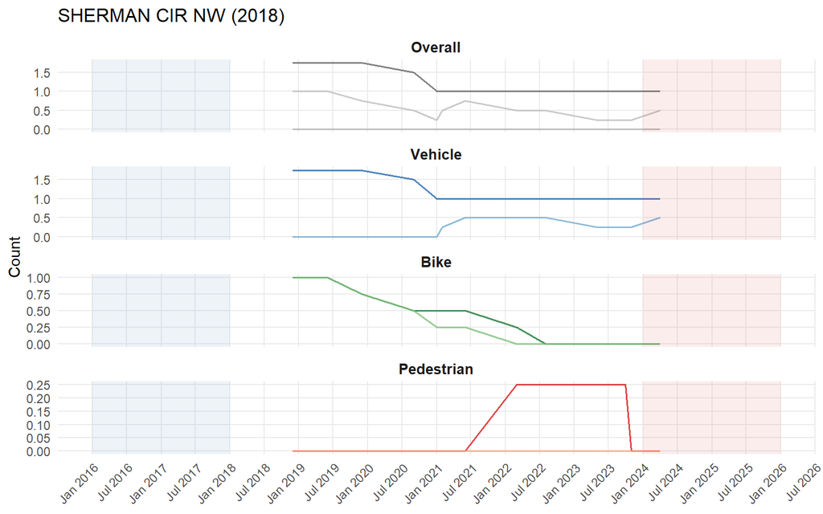

| Outcome | Before, per month | After, per month | % change |
| --- | --- | --- | --- |
| All Crashes | 0.17 | 0.04 | -75.0 |
| Injury Crashes | 0.12 | 0.04 | -66.7 |
| Serious Injury Crashes | 0.00 | 0.00 | NaN |
| Fatal Crashes | 0.00 | 0.00 | NaN |
| Vehicle Crashes | 0.17 | 0.04 | -75.0 |
| Bike Crashes | 0.12 | 0.00 | -100.0 |
| Pedestrian Crashes | 0.00 | 0.00 | NaN |
| Driver Injury | 0.00 | 0.04 | Inf |
| Bicyclist Injury | 0.12 | 0.00 | -100.0 |
| Pedestrian Injury | 0.00 | 0.00 | NaN |

**Change in micromobility usage**  
2019 micromobility trips: 0  
Avg. of ’24 & ’25 trips: 472  
Increase in trips: 472  
% increase: Inf

**VIRGINIA AVE NW (2022)**

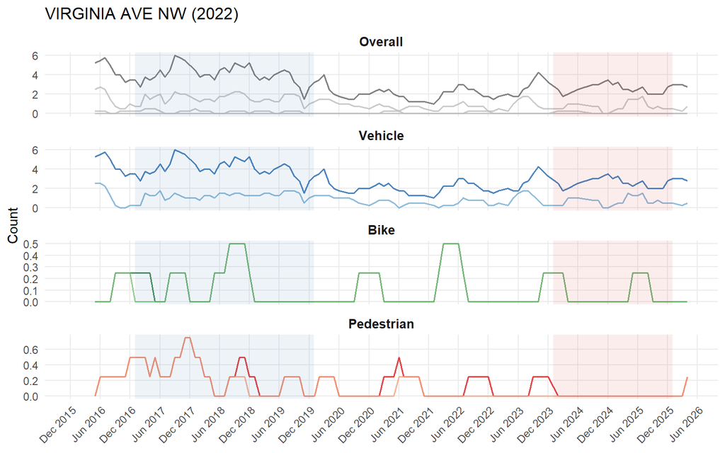

| Outcome | Before, per month | After, per month | % change |
| --- | --- | --- | --- |
| All Crashes | 4.11 | 2.21 | -46.3 |
| Injury Crashes | 1.58 | 0.62 | -60.5 |
| Serious Injury Crashes | 0.19 | 0.04 | -78.6 |
| Fatal Crashes | 0.00 | 0.00 | NaN |
| Vehicle Crashes | 4.11 | 2.21 | -46.3 |
| Bike Crashes | 0.14 | 0.04 | -70.0 |
| Pedestrian Crashes | 0.25 | 0.00 | -100.0 |
| Driver Injury | 1.25 | 0.58 | -53.3 |
| Bicyclist Injury | 0.11 | 0.04 | -62.5 |
| Pedestrian Injury | 0.22 | 0.00 | -100.0 |

**Change in micromobility usage**  
2019 micromobility trips: 136  
Avg. of ’24 & ’25 trips: 1,369  
Increase in trips: 1,233  
% increase: 907

**WARDER ST NW (2022)**

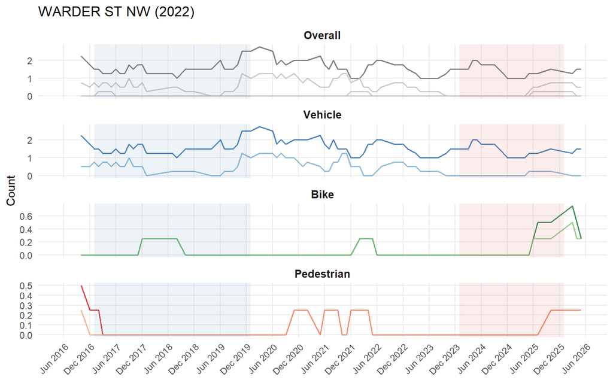

| Outcome | Before, per month | After, per month | % change |
| --- | --- | --- | --- |
| All Crashes | 1.06 | 0.79 | -25.0 |
| Injury Crashes | 0.39 | 0.12 | -67.9 |
| Serious Injury Crashes | 0.03 | 0.04 | 50.0 |
| Fatal Crashes | 0.00 | 0.00 | NaN |
| Vehicle Crashes | 1.06 | 0.79 | -25.0 |
| Bike Crashes | 0.03 | 0.08 | 200.0 |
| Pedestrian Crashes | 0.00 | 0.04 | Inf |
| Driver Injury | 0.36 | 0.04 | -88.5 |
| Bicyclist Injury | 0.03 | 0.04 | 50.0 |
| Pedestrian Injury | 0.00 | 0.04 | Inf |

**Change in micromobility usage**  
2019 micromobility trips: 0  
Avg. of ’24 & ’25 trips: 1,284  
Increase in trips: 1,284  
% increase: Inf

**WEST VIRGINIA AVE NE (2021)**

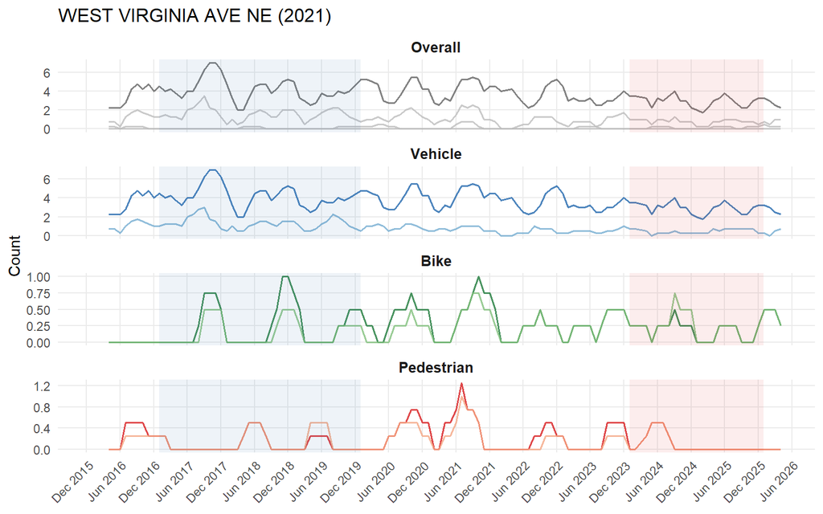

| Outcome | Before, per month | After, per month | % change |
| --- | --- | --- | --- |
| All Crashes | 4.03 | 2.79 | -30.7 |
| Injury Crashes | 1.50 | 0.67 | -55.6 |
| Serious Injury Crashes | 0.06 | 0.12 | 125.0 |
| Fatal Crashes | 0.00 | 0.00 | NaN |
| Vehicle Crashes | 4.03 | 2.79 | -30.7 |
| Bike Crashes | 0.25 | 0.17 | -33.3 |
| Pedestrian Crashes | 0.08 | 0.08 | 0.0 |
| Driver Injury | 1.25 | 0.38 | -70.0 |
| Bicyclist Injury | 0.14 | 0.21 | 50.0 |
| Pedestrian Injury | 0.11 | 0.08 | -25.0 |

**Change in micromobility usage**  
2019 micromobility trips: 128  
Avg. of ’24 & ’25 trips: 5,480  
Increase in trips: 5,352  
% increase: 4,181

## Comparing streets with these new projects against other DC streets

Maybe the decline in crashes was not particular to these corridors, and in fact happened across DC during this time? Maybe it’s all the new speed cameras, or the fact DC is towing chronic speeders? The declines we observe on bike lane streets could just be part of a bigger, District-wide trend.

To try and answer that question, let’s compare these streets with new bike lane projects to other streets in DC, and see if they have similar or different crash trends.

```r
end_of_treatment = 2023
min_year         = 2017

rs$length_m <- as.numeric(st_length(rs))

crashes_near_subblocks <-
  get_crashes_in_corridors(line_sf = rs, crashes_sf = cd, buffer_in_meters = 4) |>
  st_drop_geometry() |>
    # For crashes in multiple buffers, randomly keep one. this will add noise but if anything that will bias our effect sizes downwards.
    group_by(CRIMEID) |>
    slice_sample(n = 1) |>         # randomly pick one buffer per crash
    ungroup() |>
  # group_by(SUBBLOCKKEY, year, month, date) |>
  group_by(SUBBLOCKKEY, year) |>
  summarise(
    across(ends_with(" Crashes"), \(x) sum(x, na.rm = TRUE)),
    across(ends_with(" Injury"), \(x) sum(x, na.rm = TRUE)),
      `Total Crashes`      = n(),
      TOTALTRAVELLANES     = first(TOTALTRAVELLANES),
      TOTALPARKINGLANES    = first(TOTALPARKINGLANES),
      TOTALTRAVELLANEWIDTH = first(TOTALTRAVELLANEWIDTH),
      WARD_ID              = first(WARD_ID),
      DCFUNCTIONALCLASS    = first(DCFUNCTIONALCLASS),
    .groups   = "drop"
  ) |>
  ungroup() |>
  dplyr::left_join(
  st_drop_geometry(pbl) %>%
    mutate(
           pbl = ifelse((!is.na(BIKELANE_PROTECTED)) | (!is.na(BIKELANE_DUAL_PROTECTED)), 1, 0),
           bbl = ifelse(is.na(BIKELANE_PROTECTED)    &  is.na(BIKELANE_DUAL_PROTECTED), 1, 0)
           ) %>%
    rename(route_name = ROUTENAME) %>%
    mutate(unique_route_id = paste(route_name, build_year)) %>%
    select(SUBBLOCKKEY, build_year, pbl, bbl, route_name, unique_route_id),
  by = "SUBBLOCKKEY") |>
  dplyr::left_join(st_drop_geometry(rs) %>% select(SUBBLOCKKEY, length_m), by="SUBBLOCKKEY")


# Identify variable groups programmatically
crash_vars         <- names(crashes_near_subblocks)[
                        grepl("Crashes$|Injury$", names(crashes_near_subblocks))
                      ]
time_invariant_vars <- c("TOTALTRAVELLANES", "TOTALPARKINGLANES", "TOTALTRAVELLANEWIDTH",
                          "WARD_ID", "DCFUNCTIONALCLASS", "build_year", "pbl", "bbl",
                          "route_name", "unique_route_id", "length_m")



crashes_near_subblocks_filled <- crashes_near_subblocks |>
  filter(year >= min_year) |>
  # Complete over all SUBBLOCKKEY × existing year-month combinations
  # using nesting() so we don't invent year-month combos that don't exist in the data
  complete(
    SUBBLOCKKEY,
    # nesting(year, month, date),
    # nesting(year),
    year = min_year:2025,
    fill = setNames(as.list(rep(0, length(crash_vars))), crash_vars)
  ) |>
  # Fill time-invariant characteristics from whichever rows have data for that subblock
  group_by(SUBBLOCKKEY) |>
  fill(all_of(time_invariant_vars), .direction = "downup") |>
  mutate(
    mean_crashes_per_800_meter_pre = mean(
      `Total Crashes`[year %in% seq(min_year, 2017, 1)] / length_m[year %in% seq(min_year, 2017, 1)] * 800,
      na.rm = TRUE
    )
  ) |>
  ungroup() |>
  mutate(
    mean_crashes_per_meter_pre_bin = ntile(mean_crashes_per_800_meter_pre, 3)
  ) |>
  mutate(
    across(
      all_of(crash_vars),
      \(x) x / length_m * 800,
      .names = "{.col} per 800 meters"
    )
  ) |>
  filter(build_year %in% 2020:end_of_treatment | is.na(build_year)) |>
  filter(year %in% c(min_year:2019, (end_of_treatment+1):2025)) |>
  mutate(
    treated = if_else(is.na(build_year), 0, 1),
    post    = if_else(year > end_of_treatment, 1, 0)
  )
```

Here are the changes in means across different variables. The bike lane streets start from a higher level of crashes and, with the exception of bike crashes, see a bigger drop in crashes. (This is likely due to a large increase in bike traffic).

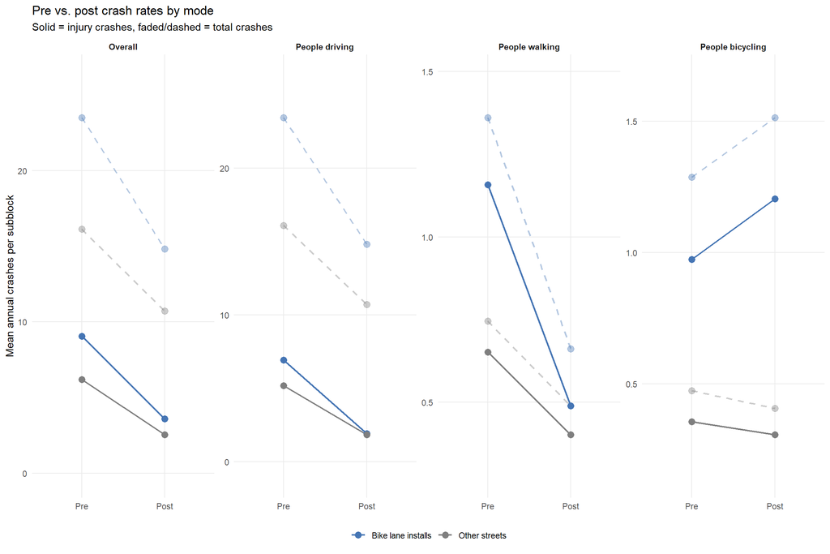

```r
crash_vars_to_plot <- c("Total Crashes per 800 meters", "Injury Crashes per 800 meters",
                         "Vehicle Crashes per 800 meters", "Driver Injury per 800 meters",
                         "Pedestrian Crashes per 800 meters", "Pedestrian Injury per 800 meters",
                        "Bike Crashes per 800 meters", "Bicyclist Injury per 800 meters")

panel_pairs <- list(
  "Overall"     = list(total = "Total Crashes per 800 meters",    injury = "Injury Crashes per 800 meters"),
  "People driving"      = list(total = "Vehicle Crashes per 800 meters",  injury = "Driver Injury per 800 meters"),
  "People walking"  = list(total = "Pedestrian Crashes per 800 meters", injury = "Pedestrian Injury per 800 meters"),
  "People bicycling"        = list(total = "Bike Crashes per 800 meters",     injury = "Bicyclist Injury per 800 meters")
)

plot_data <- map_dfr(names(panel_pairs), \(panel) {
  pair <- panel_pairs[[panel]]
  crashes_near_subblocks_filled |>
    select(treated, post, total = all_of(pair$total), injury = all_of(pair$injury)) |>
    mutate(panel = panel)
}) |>
  mutate(
    treated = if_else(treated == 1, "Bike lane installs", "Other streets"),
    post    = factor(if_else(post == 1, "Post", "Pre"), levels = c("Pre", "Post")),
    panel   = factor(panel, levels = names(panel_pairs))
  ) |>
  group_by(treated, post, panel) |>
  summarise(
    total  = mean(total,  na.rm = TRUE),
    injury = mean(injury, na.rm = TRUE),
    .groups = "drop"
  )

ggplot(plot_data, aes(x = post, group = treated, color = treated)) +
  geom_line(aes(y = total), linewidth = 0.8, alpha = 0.4, linetype = "dashed") +
  geom_point(aes(y = total), size = 3, alpha = 0.4) +
  geom_line(aes(y = injury), linewidth = 0.8) +
  geom_point(aes(y = injury), size = 3) +
  facet_wrap(~ panel,
             scales = "free_y",
             ncol = 4) +
  scale_color_manual(values = c("Other streets" = "grey50", "Bike lane installs" = "#4575b4")) +
  scale_y_continuous(expand = expansion(mult = 0.2)) +
  labs(
    x        = NULL,
    y        = "Mean annual crashes per subblock",
    color    = NULL,
    title    = "Pre vs. post crash rates by mode",
    subtitle = "Solid = injury crashes, faded/dashed = total crashes"
  ) +
  theme_minimal(base_size = 11) +
  theme(
    legend.position  = "bottom",
    panel.grid.minor = element_blank(),
    strip.text       = element_text(face = "bold")
  )
```

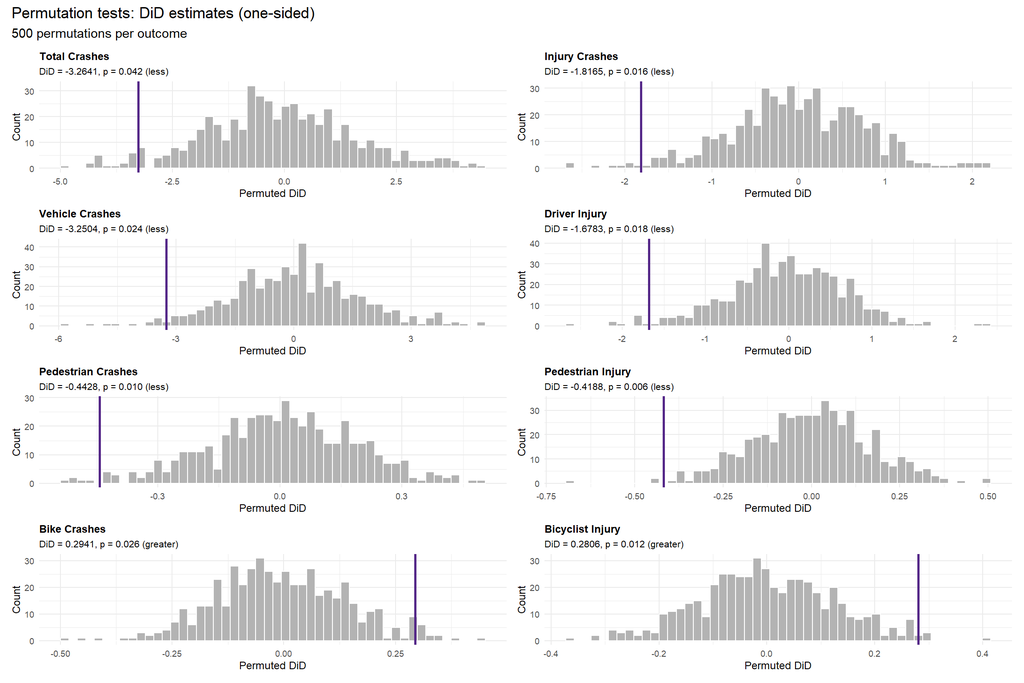

```r
# ── Observed DiD statistic ─────────────────────────────────────────────────────
compute_did <- function(df, outcome) {
  df |>
    group_by(treated, post) |>
    summarise(mean_val = mean(.data[[outcome]], na.rm = TRUE), .groups = "drop") |>
    pivot_wider(names_from = post, values_from = mean_val, names_prefix = "post_") |>
    mutate(change = post_1 - post_0) |>
    summarise(did = diff(change)) |>   # treated change minus control change
    pull(did)
}

# ── Pre-compute once ───────────────────────────────────────────────────────────
subblock_treatment <- crashes_near_subblocks_filled |> distinct(SUBBLOCKKEY, treated)
df_no_treated      <- crashes_near_subblocks_filled |> select(-treated)

# ── Permutation test function ──────────────────────────────────────────────────
run_permutation_test <- function(outcome_var, df, df_with_treated, lookup,
                                 n_permutations = 500,
                                 alternative = "less") {  # "less" or "greater"

  observed_did <- compute_did(df_with_treated, outcome_var)

  permuted_dids <- map_dbl(1:n_permutations, \(i) {
    permuted <- lookup |> mutate(treated = sample(treated))
    df |>
      left_join(permuted, by = "SUBBLOCKKEY") |>
      compute_did(outcome_var)
  })

  # One-sided p-value
  p_value <- if (alternative == "less") {
    mean(permuted_dids <= observed_did)   # H1: DiD < 0 (crashes went down)
  } else {
    mean(permuted_dids >= observed_did)   # H1: DiD > 0 (bike crashes went up)
  }

  clean_label <- str_remove(outcome_var, " per 800 meters")

  tibble(did = permuted_dids) |>
    ggplot(aes(x = did)) +
    geom_histogram(bins = 50, fill = "grey70", color = "white") +
    geom_vline(xintercept = observed_did, color = "#542788", linewidth = 1) +
    labs(
      x        = "Permuted DiD",
      y        = "Count",
      title    = clean_label,
      subtitle = sprintf("DiD = %.4f, p = %.3f (%s)", observed_did, p_value, alternative)
    ) +
    theme_minimal(base_size = 9) +
    theme(
      plot.title    = element_text(face = "bold", size = 9),
      plot.subtitle = element_text(size = 8)
    )
}

# ── Run with appropriate one-sided test per outcome ────────────────────────────
bike_vars  <- c("Bike Crashes per 800 meters", "Bicyclist Injury per 800 meters")

n = 500
plots <- map(crash_vars_to_plot, \(v) {
  run_permutation_test(
    outcome_var     = v,
    df              = df_no_treated,
    df_with_treated = crashes_near_subblocks_filled,
    lookup          = subblock_treatment,
    n_permutations  = n,
    alternative     = if_else(v %in% bike_vars, "greater", "less")
  )
})

patchwork::wrap_plots(plots, ncol = 2) +
  patchwork::plot_annotation(
    title    = "Permutation tests: DiD estimates (one-sided)",
    subtitle = sprintf("%d permutations per outcome", n)
  )
```

What’s going on with people crashing on bicycles on the bike lane streets? Part of the answer seems to be that there are just way, way more people biking on these streets than there were previously. The increase is much larger on streets that got bike lanes than on other streets.

Here are the micromobility trip totals for all road segments in DC:

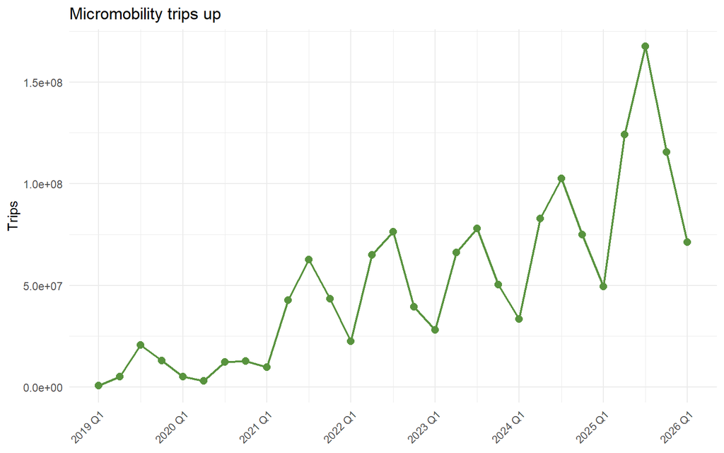

```r
to_plot <-
  mm_trips %>%
  st_drop_geometry() %>%
  summarise(across(starts_with("trips_"), sum, na.rm = TRUE)) %>%
  tidyr::pivot_longer(col = everything(), names_to = "period", values_to = "trips") %>%
    mutate(
    year    = as.integer(stringr::str_extract(period, "\\d{4}")),
    quarter = as.integer(stringr::str_extract(period, "(?<=Q)\\d")),
    time    = year + (quarter - 1) / 4,
    label   = paste0(year, " Q", quarter)
  )

ggplot(to_plot, aes(x = time, y = trips)) +
  geom_line(linewidth = 0.8, color="#58933e") +
  geom_point(size = 2.5, color="#58933e") +
  scale_x_continuous(breaks = to_plot$time[seq(1, nrow(to_plot), 4)], labels = to_plot$label[seq(1, nrow(to_plot), 4)]) +
  theme_minimal() +
  theme(axis.text.x = element_text(angle = 45, hjust = 1)) +
  labs(x=NULL, y = "Trips") +
  ggtitle("Micromobility trips up")
```

But as the chart below shows, rides have increased way more on streets that had bike lanes installed:

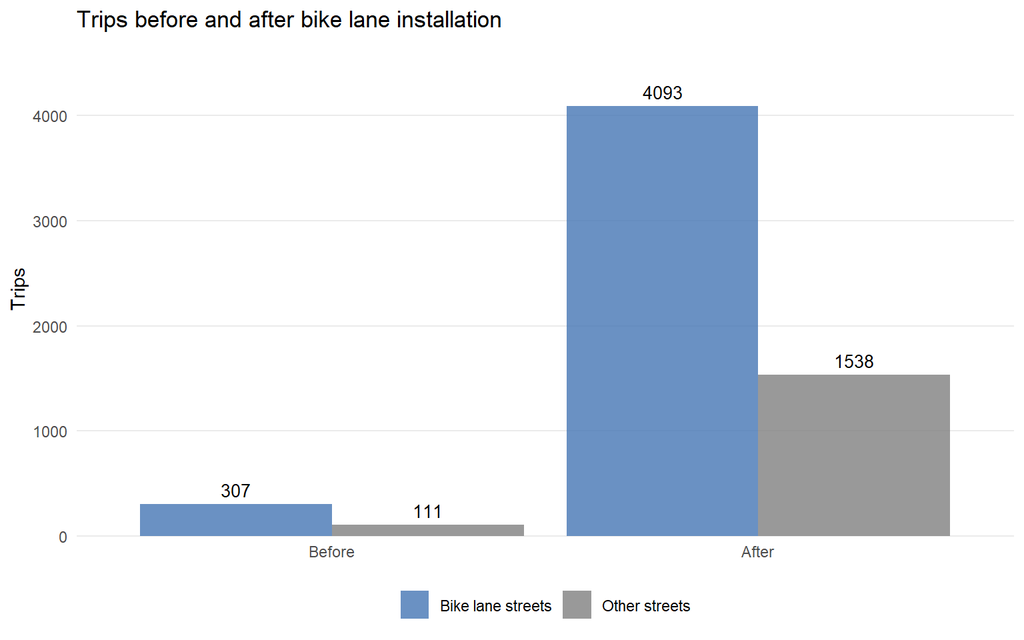

```r
crashes_near_subblocks_filled                                                  |>
  dplyr::left_join(segment_lookup, by="SUBBLOCKKEY")                           |>
  dplyr::left_join(mm_trips_tbl, by = "OBJECTID")                              |>
  group_by(treated)                                                            |>
  summarize(
    mean_2019_trips = mean(mean_2019_trips, na.rm=T),
    mean_24_25_trips = mean(mean_24_25_trips, na.rm=T)
  )                                                                            |>
  tidyr::pivot_longer(cols = -treated, names_to = "post", values_to = "trips") |>
  mutate(post = if_else(post=="mean_2019_trips", 0, 1))                        |>

  mutate(
    treated = if_else(treated == 1, "Bike lane streets", "Other streets"),
    post    = factor(if_else(post == 1, "After", "Before"), levels = c("Before", "After"))
  ) |>
  ggplot(aes(x = post, y = trips, fill = treated)) +
  geom_col(position = "dodge", alpha = 0.8) +
  geom_text(aes(label = round(trips, 0)),
            position = position_dodge(width = 0.9),
            vjust = -0.5, size = 3.5) +
  scale_fill_manual(values = c("Other streets" = "grey50", "Bike lane streets" = "#4575b4")) +
  scale_y_continuous(expand = expansion(mult = c(0, 0.15))) +
  labs(
    x    = NULL,
    y    = "Trips",
    fill = NULL,
    title = "Trips before and after bike lane installation"
  ) +
  theme_minimal(base_size = 11) +
  theme(
    legend.position  = "bottom",
    panel.grid.minor = element_blank(),
    panel.grid.major.x = element_blank()
  )
```

**Click here to see some empirical CDFs**

Here are the empirical cumulative distribution functions:

```r
# crashes_near_subblocks_filled |>
#   mutate(treated = if_else(is.na(build_year), "Other streets", "Bike lane streets")) |>
#   ggplot(aes(x = log(`Total Crashes per 800 meters`+.0001), fill = treated)) +
#   geom_density(binwidth = 1, alpha = 0.4, position = "identity") +
#   scale_fill_manual(values = c("Other streets" = "#b35806", "Bike lane streets" = "#542788"))

# crashes_near_subblocks_filled |>
#   mutate(treated = if_else(is.na(build_year), "Other streets", "Bike lane streets")) |>
#   mutate(post    = if_else(year >= 2024, "2. post", "1. pre")) |>
#   ggplot(aes(x = log(`Total Crashes per 800 meters`+.0001), fill = treated)) +
#   geom_density(binwidth = 1, alpha = 0.4, position = "identity") +
#   scale_fill_manual(values = c("Other streets" = "#b35806", "Bike lane streets" = "#542788")) +
#   facet_wrap(~post, ncol=1)


ecdf <-
  crashes_near_subblocks_filled |>
  mutate(treated = if_else(is.na(build_year), "Other streets", "Bike lane streets")) |>
  ggplot(aes(x = `Total Crashes per 800 meters`, color = treated)) +
  stat_ecdf(geom = "step") +
  scale_color_manual(values = c("Other streets" = "#b35806", "Bike lane streets" = "#542788")) +
  labs(color = NULL) +
  theme(legend.position = "top") +
  ggtitle("Empirical CDF by group, all years pooled")

ggplotly(ecdf) %>% layout(hovermode = "x")
```

[interactive chart not shown]

```r
ecdf <-
  crashes_near_subblocks_filled |>
  mutate(treated = if_else(is.na(build_year), "Other streets", "Bike lane streets")) |>
  mutate(post    = if_else(post == 1, "2. After", "1. Before")) |>
  ggplot(aes(x = `Total Crashes per 800 meters`, color = treated)) +
  stat_ecdf(geom = "step") +
  scale_color_manual(values = c("Other streets" = "#b35806", "Bike lane streets" = "#542788")) +
  labs(color = NULL) +
  facet_wrap(~post) +
  ggtitle("Empirical CDF by group, before vs. after")

ggplotly(ecdf) %>% layout(hovermode = "x")
```

[interactive chart not shown]

```r
#
# ecdf <-
#   crashes_near_subblocks_filled |>
#   mutate(treated = if_else(is.na(build_year), "Other streets", "Bike lane streets")) |>
#   mutate(post    = if_else(post == 1, "2. After", "1. Before")) |>
#   ggplot(aes(x = `Injury Crashes per 800 meters`, color = treated)) +
#   stat_ecdf(geom = "step") +
#   scale_color_manual(values = c("Other streets" = "#b35806", "Bike lane streets" = "#542788")) +
#   labs(color = NULL) +
#   facet_wrap(~post) +
#   ggtitle("Empirical CDF by group, before vs. after")
#
# ggplotly(ecdf) %>% layout(hovermode = "x")
```